# Coronavirus SARS-CoV-2 / Covid-19

[figure not shown]

[figure not shown]

[figure not shown]

[figure not shown]

[figure not shown]

[figure not shown]

[figure not shown]

[figure not shown]

[figure not shown]

[figure not shown]

[figure not shown]

[figure not shown]

[1 more figures not shown]

# World Map

### Total Confirmed for each Country

[interactive chart not shown]

### Total Deaths for each Country

[interactive chart not shown]

# Bar Chart

**Bar Charts with descending order**

[interactive chart not shown]

# Trend / Daily Change

### Worldwide

**Worldwide Cumulated Cases / Daily Changes over Time**

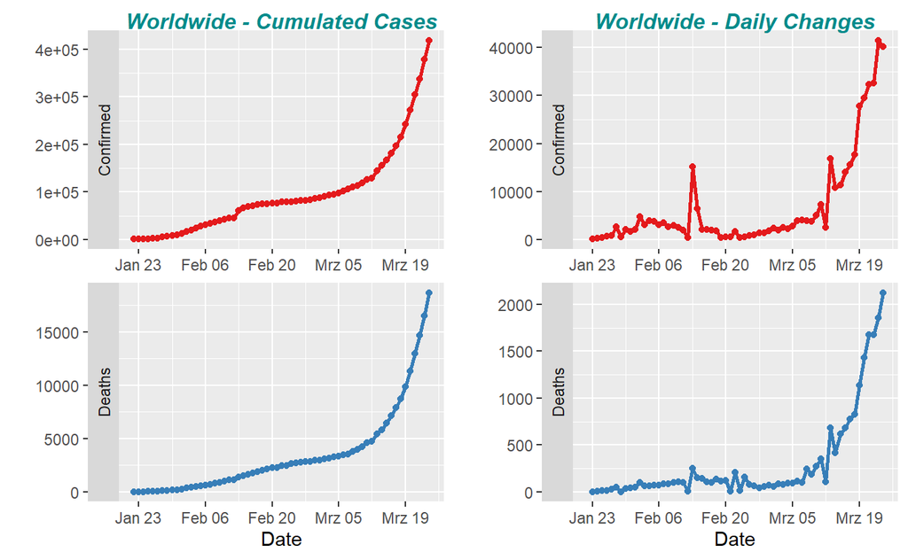

**Selected Countries - Cumulated Cases / Daily Changes over Time**

### China

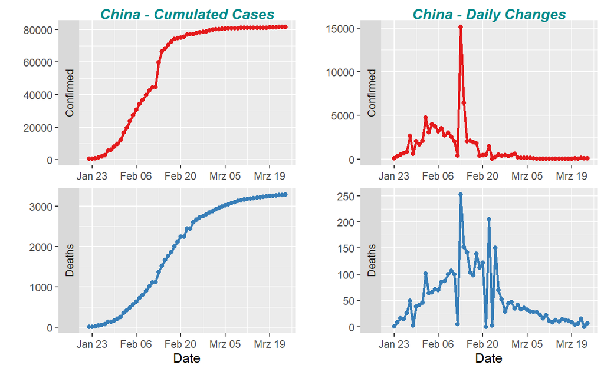

### South Korea

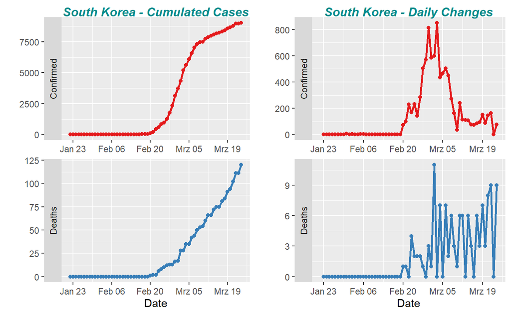

### Austria

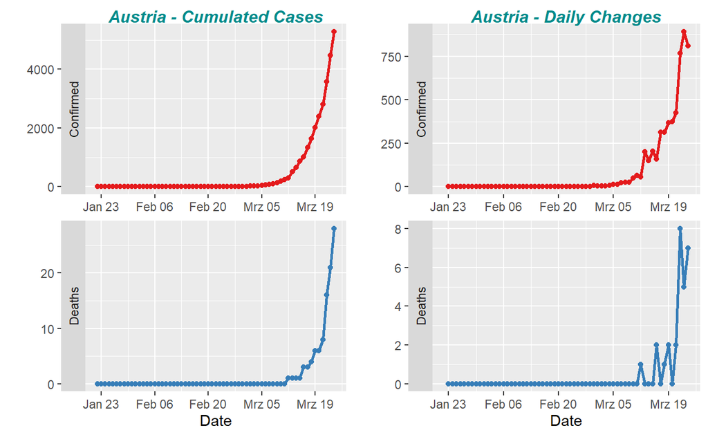

### France

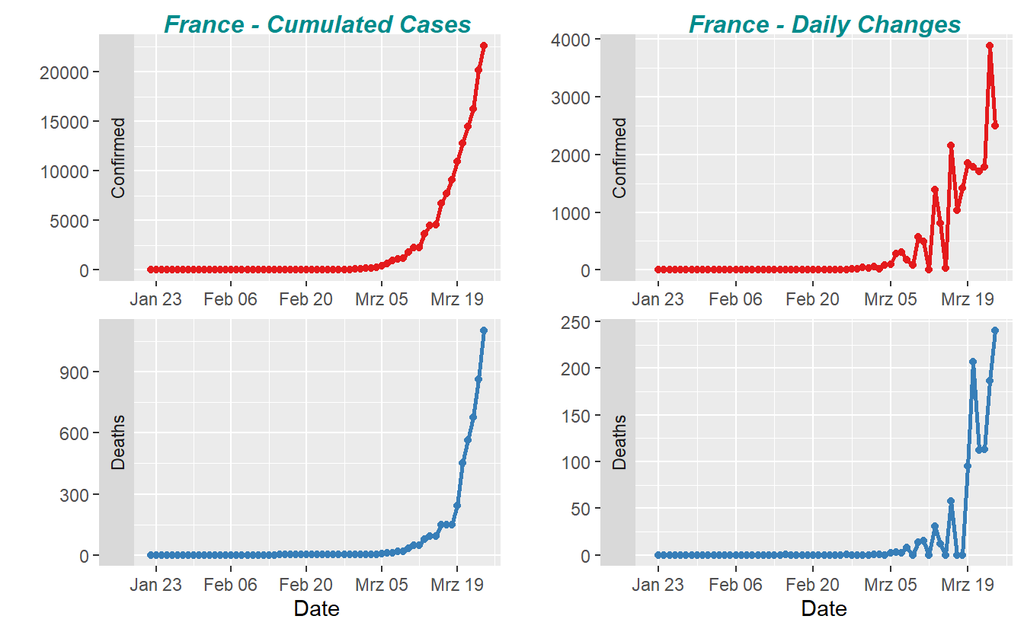

### Germany

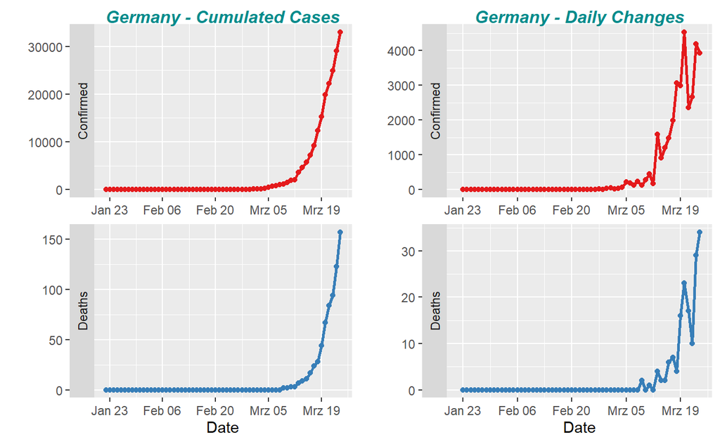

### Italy

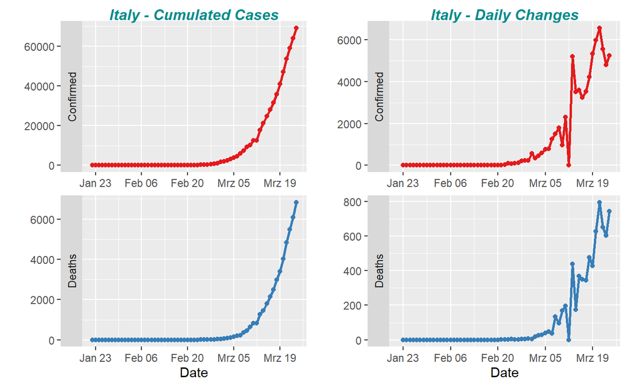

### Spain

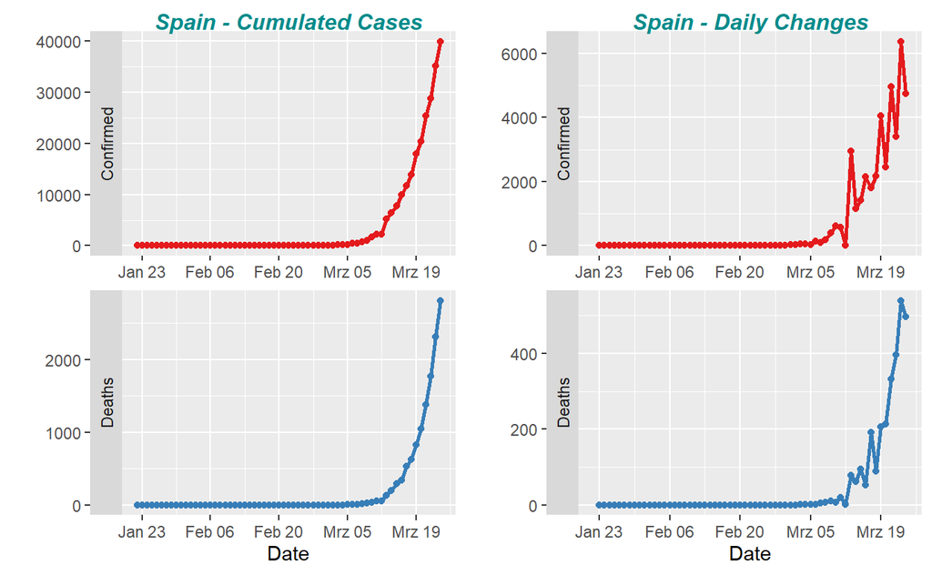

### United States of America

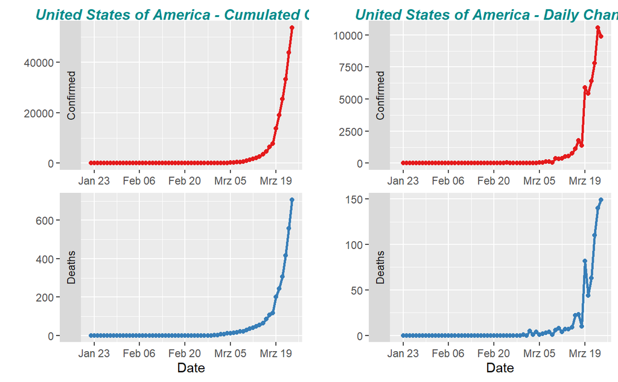

# Comparison Exponential Growth

### Comparison Exponential Growth of selected Countries

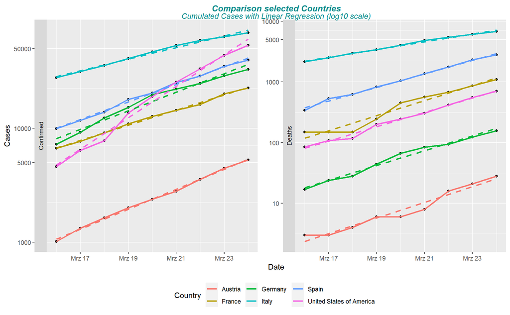

### Estimation speed of spread of the Coronavirus with Linear Regression

**Exponential Growth and Doubling Time $T$**

Exponential growth over time can be fitted by linear regression if the logarithms of the case numbers is taken. Generally, exponential growth corresponds to linearly growth over time for the log (to any base) data.

The semi-logorithmic plot with base-10 log scale for the Y axis shows functions following an exponential law $y(t) = y_0 * a^{t/\tau}$ as straight lines. The time constant $\tau$ describes the time required for y to increase by one factor of $a$.

If e.g. the confirmed or death cases are growing in $t-days$ by a factor of $10$ the doubling time $T \widehat{=} \tau$ can be calculated with $a \widehat{=} 2$ by

$T[days] = \frac {t[days] * log_{10}(2)} {log_{10}(y(t))-log_{10}(y_0)}$

with

$log_{10}(y(t))-log_{10}(y_0) = = log_{10}(y(t))/y_0) = log_{10}(10*y_0/y_0) = 1$

and doubling time

$T[days] = t[days] * log_{10}(2) \approx t[days] * 0.30$.

The *doubling time $T$* and the *Forecast* is calculated for following selected countries: **Austria, France, Germany, Italy, Spain, United States of America**

### Germany - Example plot with ~linear slope on a log10 scale

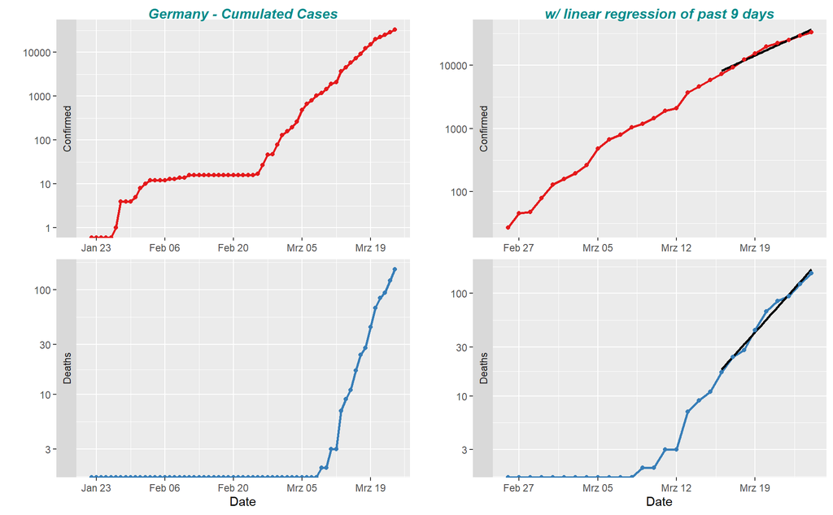

### Germany - Trend with Forecast on a linear scale

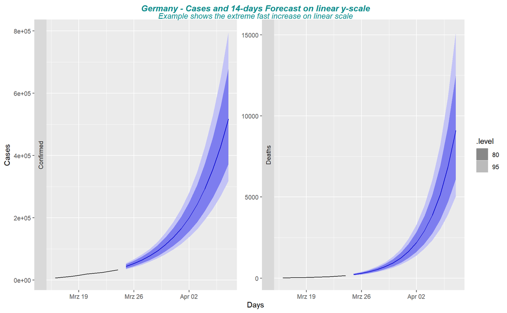

### Forecast Plot - next 14 days

The plot shows the extreme forecast increase in case of unchecked exponentiell growth. The dark shaded regions show 80% rsp. 95% prediction intervals. These prediction intervals are displaying the uncertainty in forecasts based on the linear regression over the past 9 days.

# Table Doubling Time / Forecast

**Doubling Time and Forecast**

The forecasted cases for the next 14 days are calculated ‘only’ from the linear regression of the logarithmic data and are not considering any effects of measures in place. In addition data inaccuracies are not taken into account, especially relevant for the confirmed cases.

Therefore the 14 days forecast is only an indication for the direction of an unchecked exponentiell growth.

Forecast (FC) with linear regression: Doubling Time (days), Forecasted cases tomorrow and Forecasted cases in 14 days

| Country | Case_Type | T_doubling | last_day | FC_next_day | FC_14days |
| --- | --- | --- | --- | --- | --- |
| Austria | Confirmed | 3.4 | 5283 | 6561 | 90493 |
| France | Confirmed | 4.5 | 22622 | 26702 | 195289 |
| Germany | Confirmed | 3.7 | 32986 | 44010 | 504235 |
| Italy | Confirmed | 5.9 | 69176 | 81829 | 374416 |
| Spain | Confirmed | 3.9 | 39885 | 49498 | 496584 |
| United States of America | Confirmed | 2.2 | 53740 | 83654 | 5240831 |
| Austria | Deaths | 2.3 | 28 | 34 | 1626 |
| France | Deaths | 2.4 | 1102 | 1544 | 63195 |
| Germany | Deaths | 2.5 | 157 | 227 | 8764 |
| Italy | Deaths | 4.7 | 6820 | 8275 | 56065 |
| Spain | Deaths | 2.7 | 2808 | 3796 | 107164 |
| United States of America | Deaths | 2.5 | 706 | 938 | 32345 |

Forecast (FC) with linear regression: Doubling Time (days), Forecasted cases tomorrow and Forecasted cases in 14 days

| Country | Case_Type | T_doubling | last_day | FC_next_day | FC_14days |
| --- | --- | --- | --- | --- | --- |
| World | Confirmed | 6.5 | 418678 | 465404 | 1872851 |
| World | Deaths | 5.7 | 18625 | 21017 | 103542 |

### Check of Forecast Accuracy

The forecast accuracy is checked by using the forecast method for the nine days before the past three days (*training data*). Subsequent forecasting of the past three days enables comparison with the real data of these days (*test data*).

The comparison is also an early indicator if the *exponential growth* is declining.

### Germany - Forecast Accuracy for past three days

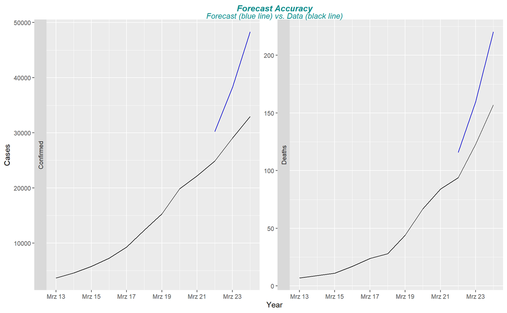

# References

**Data Source**

Data files are provided by **Johns Hopkins University** on GitHub  
https://github.com/CSSEGISandData/COVID-19/tree/master/csse_covid_19_data/csse_covid_19_time_series

- Data files as of 2020-03-24:  
  *time_series_covid19_confirmed_global.csv*,  
  *time_series_covid19_deaths_global*

Note: as of 2020-03-24 the data files used so far will no longer be updated. They have releaseed a new data structure which does no longer provide the recovered cases.

- Data files up to 2020-03-23:  
  *time_series_covid_19_confirmed.csv*,  
  *time_series_covid_19_deaths.csv*  
  *time_series_covid_19_recovered.csv*

The data are visualized on their excellent Dashboard  
**Johns Hopkins University Dashboard**  
https://coronavirus.jhu.edu/map.html

Files are also provided on  
**Novel Corona Virus 2019 Dataset - Day level information on covid-19 affected cases**  
https://www.kaggle.com/sudalairajkumar/novel-corona-virus-2019-dataset

**Further links**

**WHO Dashboard**  
https://experience.arcgis.com/experience/685d0ace521648f8a5beeeee1b9125cd

**Robert Koch Institut, Germany**  
https://www.rki.de/DE/Content/InfAZ/N/Neuartiges_Coronavirus/Fallzahlen.html?nn=13490888

**Wikipedia - Exponential Growth** https://en.wikipedia.org/wiki/Exponential_growth

**Code Source**

Code is based on ideas from https://rpubs.com/TimoBoll/583802